# Analyzing yeast RNAseq data

JF GOUT

# Gene expression in budding yeast responding to alcohols with and without oxygen

The goal of this lab is to analyze transcriptomic data from a previously published dataset. The data used in this lab comes from a paper published in 2018: **Genotype-by-Environment-by-Environment Interactions in the *Saccharomyces cerevisiae* Transcriptomic Response to Alcohols and Anaerobiosis** (https://pubmed.ncbi.nlm.nih.gov/30301737/)

The full dataset is available on NCBI GEO/SRA (two linked databases that contain Gene Expression/Short Read sequences data) at: https://www.ncbi.nlm.nih.gov/geo/query/acc.cgi?acc=GSE118069

The data is made of RNAseq reads from several yeast strains (IL01, NCY3290 and Y7568), grown in different media (agents: Butanol, Ethanol, Isobutanol, YPD) under aerobic or anaerobic condition.

While the analyzes done in this paper are fairly complex (due to the multi-factorial design of the experiment), **we will focus on differences in gene expression between aerobic and anaerobic growth conditions** and compare the results obtained with those of the 2006 study presented in class (https://pubmed.ncbi.nlm.nih.gov/17322208/).

## Initial quantification step

Many RNAseq pipelines use the tool **tophat2** to map reads to a reference genome and then **cufflinks** to estimate the abundance (RPKM or FPKM) of each gene. Here, we will use the new generation of tools that use **pseudoalignment**. Pseudoalignement relies on kmers to find the most likely transcript origin for each sequencing read (see: https://pachterlab.github.io/kallisto/about and https://tinyheero.github.io/2015/09/02/pseudoalignments-kallisto.html). These methods are a LOT faster than traditional alignment methods.  
The program used here to perform this step is **Kallisto** (https://pachterlab.github.io/kallisto/manual). All the sequencing files are pre-downloaded and available in: **/mnt/scratch/goutfs/CMB8013/RNAseq/SRP156315/**

Our first step will be to run the **Kallisto** pseudomapping program for each of these files. Kallisto requires a first step of **indexing** the sequences against which RNAseq reads will be pseduomapped. The index is already available at: **/mnt/scratch/goutfs/CMB8013/RNAseq/index/transcripts.idx**. It was obtained with:

```bash
cd /mnt/scratch/goutfs/CMB8013/RNAseq/index
module load Kallisto
kallisto index -i transcripts.idx Saccharomyces_cerevisiae.R64-1-1.cdna.all.fa.gz
```

### Exercise: write a bash script to automatically run Kallisto on each sequencing file.

The file **Saccharomyces_cerevisiae.R64-1-1.cdna.all.fa.gz** contains all the predicted transcripts for the yeast genome and was downloaded from the ensembl website.  
The pseudomapping/quantification step is performed with the following general command (for unpaired reads of size 300 with sd 50):

```bash
kallisto quant -i [indexFile] -o [outputFolder] --single -l 300 -s 50 [reads.fastq.gz]
```

It would be quite cumbersome to type this command 48 times (for the 48 files that need to be processed). Therefore, we will write a bash script to automatize this process. The general structure of the script should be as follows:

```bash
#!/bin/bash

For each of the SRR*.fastq files
  Extract the SRR number from the file name --> to be used for the output folder name
  Prepare file names for slurm, log and err (for example: slurm_SRR7642939.sh, SRR7642939.log and SRR7642939.err)
  Write the corresponding slurm command into the slurm file
  submit the slurm file to the queue
done
```

For the second part of this lab, you will need to have the files generated by Kallisto. If you ran into some issues with this first part, you can download the corresponding files (solution) from: **/mnt/scratch/goutfs/CMB8013/RNAseq/Abundances**  
You will also need to use a brief summary of the experiment, which is available in the text-tabulated file: **/mnt/scratch/goutfs/CMB8013/RNAseq/experiment.tab**  
I’m also providing the file matching transcript IDs to gene IDs here: **/mnt/scratch/goutfs/CMB8013/RNAseq/gene_transcript_link.tab**

You can download these files to your computer and work locally or perform all the steps on Lugh.

## Analysis in R

This roadmap is following the steps given in the official DESeq2 tutorial available here: http://bioconductor.org/packages/devel/bioc/vignettes/DESeq2/inst/doc/DESeq2.html

### Preparing the data:

Let’s load all the packages needed for the analysis. These packages will allow us to perform the differential gene expression analysis but also to query online databases and obtain the list of genes/transcripts from a given organism (in this case: the yeast *Saccharomyces cerevisiae*).

```r
# Make sure that all these libraries are installed:
  library(tximport)
  library(DESeq2)
  library(ggplot2)
  library(pheatmap)
  library(dplyr)
  library(readr)
  library(clusterProfiler)
  library(org.Sc.sgd.db)
  library(apeglm)
```

Look at the content of the experiment.tab file:

```r
# -----------------------------
# INPUT FILES
# -----------------------------
metadata_file <- "experiment.tab"   # sample table
kallisto_dir  <- "Kallisto"       # base folder (where all the abundance files are located)
tx2gene_file  <- "gene_transcript_link.tab"    # transcript -> gene mapping

# -----------------------------
# LOAD METADATA
# -----------------------------
meta <- read.table(metadata_file, stringsAsFactors = FALSE, sep = "\t", h=T)
```

| Run | agent | BioProject | BioSample | SampleName | Strain | oxy |
| --- | --- | --- | --- | --- | --- | --- |
| SRR7642929 | YPD | PRJNA484406 | SAMN09764590 | GSM3318008 | Y7568 | AER |
| SRR7642930 | YPD | PRJNA484406 | SAMN09764636 | GSM3318009 | Y7568 | AER |
| SRR7642931 | YPD | PRJNA484406 | SAMN09764635 | GSM3318010 | NCY3290 | ANAE |
| SRR7642932 | YPD | PRJNA484406 | SAMN09764634 | GSM3318011 | NCY3290 | ANAE |
| SRR7642933 | YPD | PRJNA484406 | SAMN09764633 | GSM3318012 | NCY3290 | AER |
| SRR7642934 | Isobutanol | PRJNA484406 | SAMN09764632 | GSM3318013 | NCY3290 | ANAE |
| SRR7642935 | Isobutanol | PRJNA484406 | SAMN09764631 | GSM3318014 | NCY3290 | ANAE |
| SRR7642936 | YPD | PRJNA484406 | SAMN09764629 | GSM3318015 | NCY3290 | AER |
| SRR7642937 | YPD | PRJNA484406 | SAMN09764628 | GSM3318016 | IL01 | AER |
| SRR7642938 | Butanol | PRJNA484406 | SAMN09764627 | GSM3318017 | Y7568 | AER |
| SRR7642939 | Butanol | PRJNA484406 | SAMN09764626 | GSM3318018 | Y7568 | AER |
| SRR7642940 | Isobutanol | PRJNA484406 | SAMN09764625 | GSM3318019 | IL01 | ANAE |
| SRR7642941 | Isobutanol | PRJNA484406 | SAMN09764630 | GSM3318020 | IL01 | ANAE |
| SRR7642942 | Butanol | PRJNA484406 | SAMN09764623 | GSM3318021 | NCY3290 | ANAE |
| SRR7642943 | Butanol | PRJNA484406 | SAMN09764589 | GSM3318022 | NCY3290 | ANAE |
| SRR7642944 | Butanol | PRJNA484406 | SAMN09764619 | GSM3318023 | IL01 | AER |
| SRR7642945 | Butanol | PRJNA484406 | SAMN09764618 | GSM3318024 | IL01 | AER |
| SRR7642946 | YPD | PRJNA484406 | SAMN09764617 | GSM3318025 | Y7568 | ANAE |
| SRR7642947 | YPD | PRJNA484406 | SAMN09764624 | GSM3318026 | Y7568 | ANAE |
| SRR7642948 | Ethanol | PRJNA484406 | SAMN09764616 | GSM3318027 | NCY3290 | AER |
| SRR7642949 | Ethanol | PRJNA484406 | SAMN09764615 | GSM3318028 | NCY3290 | AER |
| SRR7642950 | YPD | PRJNA484406 | SAMN09764614 | GSM3318029 | IL01 | ANAE |
| SRR7642951 | YPD | PRJNA484406 | SAMN09764613 | GSM3318030 | IL01 | ANAE |
| SRR7642952 | Isobutanol | PRJNA484406 | SAMN09764612 | GSM3318031 | IL01 | AER |
| SRR7642953 | Isobutanol | PRJNA484406 | SAMN09764611 | GSM3318032 | Y7568 | AER |
| SRR7642954 | Isobutanol | PRJNA484406 | SAMN09764610 | GSM3318033 | Y7568 | AER |
| SRR7642955 | Butanol | PRJNA484406 | SAMN09764609 | GSM3318034 | NCY3290 | AER |
| SRR7642956 | Butanol | PRJNA484406 | SAMN09764608 | GSM3318035 | NCY3290 | AER |
| SRR7642957 | Ethanol | PRJNA484406 | SAMN09764607 | GSM3318036 | Y7568 | AER |
| SRR7642958 | Ethanol | PRJNA484406 | SAMN09764606 | GSM3318037 | Y7568 | AER |
| SRR7642959 | Isobutanol | PRJNA484406 | SAMN09764605 | GSM3318038 | NCY3290 | AER |
| SRR7642960 | Ethanol | PRJNA484406 | SAMN09764604 | GSM3318039 | Y7568 | ANAE |
| SRR7642961 | Ethanol | PRJNA484406 | SAMN09764603 | GSM3318040 | Y7568 | ANAE |
| SRR7642962 | Isobutanol | PRJNA484406 | SAMN09764602 | GSM3318041 | NCY3290 | AER |
| SRR7642963 | Ethanol | PRJNA484406 | SAMN09764601 | GSM3318042 | IL01 | AER |
| SRR7642964 | Ethanol | PRJNA484406 | SAMN09764600 | GSM3318043 | IL01 | AER |
| SRR7642965 | Isobutanol | PRJNA484406 | SAMN09764599 | GSM3318044 | IL01 | AER |
| SRR7642966 | Isobutanol | PRJNA484406 | SAMN09764598 | GSM3318045 | Y7568 | ANAE |
| SRR7642967 | Isobutanol | PRJNA484406 | SAMN09764597 | GSM3318046 | Y7568 | ANAE |
| SRR7642968 | Ethanol | PRJNA484406 | SAMN09764596 | GSM3318047 | NCY3290 | ANAE |
| SRR7642969 | Ethanol | PRJNA484406 | SAMN09764595 | GSM3318048 | NCY3290 | ANAE |
| SRR7642970 | Butanol | PRJNA484406 | SAMN09764594 | GSM3318049 | Y7568 | ANAE |
| SRR7642971 | Ethanol | PRJNA484406 | SAMN09764593 | GSM3318050 | IL01 | ANAE |
| SRR7642972 | Ethanol | PRJNA484406 | SAMN09764592 | GSM3318051 | IL01 | ANAE |
| SRR7642973 | Butanol | PRJNA484406 | SAMN09764591 | GSM3318052 | Y7568 | ANAE |
| SRR7642974 | YPD | PRJNA484406 | SAMN09764622 | GSM3318053 | IL01 | AER |
| SRR7642975 | Butanol | PRJNA484406 | SAMN09764621 | GSM3318054 | IL01 | ANAE |
| SRR7642976 | Butanol | PRJNA484406 | SAMN09764620 | GSM3318055 | IL01 | ANAE |

In this experiment, multiple variables change from one sample to the other: the **agent** (YPD, Isobutanol, Butanol or Ethanol), the **strain** and the **growth condition** (aerobic vs anaerobic, column “oxy”).

We will turn the data in these column into **factors** (required by downstream functions) and also clean up the table (remove uncecessary columns):

```r
# Ensure factors
meta$agent  <- factor(meta$agent)
meta$Strain <- factor(meta$Strain)
meta$oxy    <- factor(meta$oxy, levels = c("AER", "ANAE"))


# Basic cleanup for readable sample IDs
meta$agent_clean  <- gsub("[^A-Za-z0-9]+", "_", meta$agent)
meta$Strain_clean <- gsub("[^A-Za-z0-9]+", "_", meta$Strain)
meta$oxy_clean    <- gsub("[^A-Za-z0-9]+", "_", meta$oxy)

meta <- meta |>
  dplyr::group_by(agent_clean, Strain_clean, oxy_clean) |>
  dplyr::mutate(rep_num = dplyr::row_number()) |>
  dplyr::ungroup()

# Human-readable sample ID for plots / heatmaps
meta$sample_id <- paste0(
  meta$agent_clean, "_",
  meta$Strain_clean, "_",
  meta$oxy_clean, "-",
  meta$rep_num
)

# Keeping only useful columns
meta <- meta %>%
  dplyr::select(Run, agent, Strain, oxy, rep_num, sample_id)


# Keep factors for modeling
meta$agent  <- factor(meta$agent)
meta$Strain <- factor(meta$Strain)
meta$oxy    <- factor(meta$oxy, levels = c("AER", "ANAE"))


# Create readable sample ID
meta <- meta %>%
  group_by(agent, Strain, oxy) %>%
  mutate(rep_num = row_number()) %>%
  ungroup() %>%
  mutate(sample_id = paste0(agent, "_", Strain, "_", oxy, "-", rep_num))

# Convert to data.frame BEFORE setting rownames
# Because tibbles don't allow rownames, we move back to a data.frame
meta <- as.data.frame(meta)
rownames(meta) <- meta$sample_id


kable(meta)
```

|  | Run | agent | Strain | oxy | rep_num | sample_id |
| --- | --- | --- | --- | --- | --- | --- |
| YPD_Y7568_AER-1 | SRR7642929 | YPD | Y7568 | AER | 1 | YPD_Y7568_AER-1 |
| YPD_Y7568_AER-2 | SRR7642930 | YPD | Y7568 | AER | 2 | YPD_Y7568_AER-2 |
| YPD_NCY3290_ANAE-1 | SRR7642931 | YPD | NCY3290 | ANAE | 1 | YPD_NCY3290_ANAE-1 |
| YPD_NCY3290_ANAE-2 | SRR7642932 | YPD | NCY3290 | ANAE | 2 | YPD_NCY3290_ANAE-2 |
| YPD_NCY3290_AER-1 | SRR7642933 | YPD | NCY3290 | AER | 1 | YPD_NCY3290_AER-1 |
| Isobutanol_NCY3290_ANAE-1 | SRR7642934 | Isobutanol | NCY3290 | ANAE | 1 | Isobutanol_NCY3290_ANAE-1 |
| Isobutanol_NCY3290_ANAE-2 | SRR7642935 | Isobutanol | NCY3290 | ANAE | 2 | Isobutanol_NCY3290_ANAE-2 |
| YPD_NCY3290_AER-2 | SRR7642936 | YPD | NCY3290 | AER | 2 | YPD_NCY3290_AER-2 |
| YPD_IL01_AER-1 | SRR7642937 | YPD | IL01 | AER | 1 | YPD_IL01_AER-1 |
| Butanol_Y7568_AER-1 | SRR7642938 | Butanol | Y7568 | AER | 1 | Butanol_Y7568_AER-1 |
| Butanol_Y7568_AER-2 | SRR7642939 | Butanol | Y7568 | AER | 2 | Butanol_Y7568_AER-2 |
| Isobutanol_IL01_ANAE-1 | SRR7642940 | Isobutanol | IL01 | ANAE | 1 | Isobutanol_IL01_ANAE-1 |
| Isobutanol_IL01_ANAE-2 | SRR7642941 | Isobutanol | IL01 | ANAE | 2 | Isobutanol_IL01_ANAE-2 |
| Butanol_NCY3290_ANAE-1 | SRR7642942 | Butanol | NCY3290 | ANAE | 1 | Butanol_NCY3290_ANAE-1 |
| Butanol_NCY3290_ANAE-2 | SRR7642943 | Butanol | NCY3290 | ANAE | 2 | Butanol_NCY3290_ANAE-2 |
| Butanol_IL01_AER-1 | SRR7642944 | Butanol | IL01 | AER | 1 | Butanol_IL01_AER-1 |
| Butanol_IL01_AER-2 | SRR7642945 | Butanol | IL01 | AER | 2 | Butanol_IL01_AER-2 |
| YPD_Y7568_ANAE-1 | SRR7642946 | YPD | Y7568 | ANAE | 1 | YPD_Y7568_ANAE-1 |
| YPD_Y7568_ANAE-2 | SRR7642947 | YPD | Y7568 | ANAE | 2 | YPD_Y7568_ANAE-2 |
| Ethanol_NCY3290_AER-1 | SRR7642948 | Ethanol | NCY3290 | AER | 1 | Ethanol_NCY3290_AER-1 |
| Ethanol_NCY3290_AER-2 | SRR7642949 | Ethanol | NCY3290 | AER | 2 | Ethanol_NCY3290_AER-2 |
| YPD_IL01_ANAE-1 | SRR7642950 | YPD | IL01 | ANAE | 1 | YPD_IL01_ANAE-1 |
| YPD_IL01_ANAE-2 | SRR7642951 | YPD | IL01 | ANAE | 2 | YPD_IL01_ANAE-2 |
| Isobutanol_IL01_AER-1 | SRR7642952 | Isobutanol | IL01 | AER | 1 | Isobutanol_IL01_AER-1 |
| Isobutanol_Y7568_AER-1 | SRR7642953 | Isobutanol | Y7568 | AER | 1 | Isobutanol_Y7568_AER-1 |
| Isobutanol_Y7568_AER-2 | SRR7642954 | Isobutanol | Y7568 | AER | 2 | Isobutanol_Y7568_AER-2 |
| Butanol_NCY3290_AER-1 | SRR7642955 | Butanol | NCY3290 | AER | 1 | Butanol_NCY3290_AER-1 |
| Butanol_NCY3290_AER-2 | SRR7642956 | Butanol | NCY3290 | AER | 2 | Butanol_NCY3290_AER-2 |
| Ethanol_Y7568_AER-1 | SRR7642957 | Ethanol | Y7568 | AER | 1 | Ethanol_Y7568_AER-1 |
| Ethanol_Y7568_AER-2 | SRR7642958 | Ethanol | Y7568 | AER | 2 | Ethanol_Y7568_AER-2 |
| Isobutanol_NCY3290_AER-1 | SRR7642959 | Isobutanol | NCY3290 | AER | 1 | Isobutanol_NCY3290_AER-1 |
| Ethanol_Y7568_ANAE-1 | SRR7642960 | Ethanol | Y7568 | ANAE | 1 | Ethanol_Y7568_ANAE-1 |
| Ethanol_Y7568_ANAE-2 | SRR7642961 | Ethanol | Y7568 | ANAE | 2 | Ethanol_Y7568_ANAE-2 |
| Isobutanol_NCY3290_AER-2 | SRR7642962 | Isobutanol | NCY3290 | AER | 2 | Isobutanol_NCY3290_AER-2 |
| Ethanol_IL01_AER-1 | SRR7642963 | Ethanol | IL01 | AER | 1 | Ethanol_IL01_AER-1 |
| Ethanol_IL01_AER-2 | SRR7642964 | Ethanol | IL01 | AER | 2 | Ethanol_IL01_AER-2 |
| Isobutanol_IL01_AER-2 | SRR7642965 | Isobutanol | IL01 | AER | 2 | Isobutanol_IL01_AER-2 |
| Isobutanol_Y7568_ANAE-1 | SRR7642966 | Isobutanol | Y7568 | ANAE | 1 | Isobutanol_Y7568_ANAE-1 |
| Isobutanol_Y7568_ANAE-2 | SRR7642967 | Isobutanol | Y7568 | ANAE | 2 | Isobutanol_Y7568_ANAE-2 |
| Ethanol_NCY3290_ANAE-1 | SRR7642968 | Ethanol | NCY3290 | ANAE | 1 | Ethanol_NCY3290_ANAE-1 |
| Ethanol_NCY3290_ANAE-2 | SRR7642969 | Ethanol | NCY3290 | ANAE | 2 | Ethanol_NCY3290_ANAE-2 |
| Butanol_Y7568_ANAE-1 | SRR7642970 | Butanol | Y7568 | ANAE | 1 | Butanol_Y7568_ANAE-1 |
| Ethanol_IL01_ANAE-1 | SRR7642971 | Ethanol | IL01 | ANAE | 1 | Ethanol_IL01_ANAE-1 |
| Ethanol_IL01_ANAE-2 | SRR7642972 | Ethanol | IL01 | ANAE | 2 | Ethanol_IL01_ANAE-2 |
| Butanol_Y7568_ANAE-2 | SRR7642973 | Butanol | Y7568 | ANAE | 2 | Butanol_Y7568_ANAE-2 |
| YPD_IL01_AER-2 | SRR7642974 | YPD | IL01 | AER | 2 | YPD_IL01_AER-2 |
| Butanol_IL01_ANAE-1 | SRR7642975 | Butanol | IL01 | ANAE | 1 | Butanol_IL01_ANAE-1 |
| Butanol_IL01_ANAE-2 | SRR7642976 | Butanol | IL01 | ANAE | 2 | Butanol_IL01_ANAE-2 |

### Importing the abundance estimates and running DESeq2:

We will now import the data from all the abundance files (the output from Kallisto) and pass it to DESeq2 to perform the differential gene expression analysis. DESeq2 will estimate the dispersion (= how much variation there is between replicates) and estimate the significance of differences in abundance for each gene.

DESeq2 requires a model to represent which variable we want to test. For example, if we had only one variable (oxy) and two possible values (AER and ANAE), our model would be: **design = ~oxy** (the name of the column that contains the information for this parameter).

Here, there are multiple parameters that change between the sample. We provide this information to DESeq2, while making sure that **oxy** is the most important one by listing the parameters in the model and keeping **oxy** for the last position: **design = ~ agent + Strain + oxy**

```r
# -----------------------------
# BUILD FILE LIST
# -----------------------------
files <- file.path(paste("Kallisto/", meta$Run, ".tsv", sep = ""))
names(files) <- meta$sample_id

# -----------------------------
# LOAD tx2gene
# -----------------------------
tx2gene <- read_tsv(tx2gene_file, col_names = TRUE)

# -----------------------------
# IMPORT KALLISTO
# -----------------------------
txi <- tximport(files, type = "kallisto", tx2gene = tx2gene)


# Creating the DESeq dataset:
# The most important part here is the "design" formula which tells DESeq2 that we are interested in contrasting aerobic vs anaerobic (column "oxy") but that it should know that two other variables (agent and Strain) can contribute to the variance in expression level.
dds <- DESeqDataSetFromTximport(txi,
                               colData = meta,
                               design = ~ agent + Strain + oxy)

# Keeping only genes with at least 10 reads mapped
dds <- dds[rowSums(counts(dds)) > 10, ]
dds <- DESeq(dds)
res <- results(dds, contrast = c("oxy", "ANAE", "AER"))
res <- lfcShrink(dds, coef = "oxy_ANAE_vs_AER", type = "apeglm")
```

### Exercise:

How many genes have a significant differential expression between aerobic and anaerobic growth (at the alpha level of 0.05) before and after correction for multiple testing?

Why is it important to perform a correction for multiple testing?

### Quality control:

We will now run a number of tests to check the quality of our data. One important parameter is the replicability of measured expression levels between samples obtained in the same conditions (= same strain+agent+oxygen)

Let’s start with a simple PCA plot of the entire dataset:

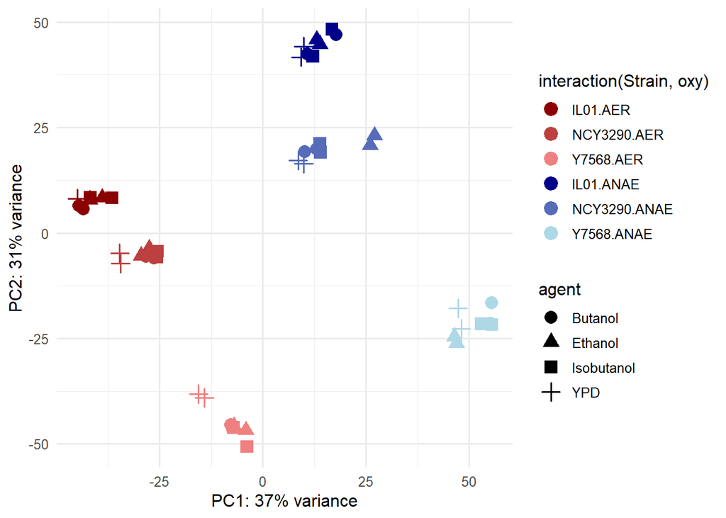

**Question:** Based on this PCA plot, which parameter has the largest effect on the transcriptome of yeast cells? (options are: strain, agent or oxy)

We can also use heatmaps showing the distance or the correlation coefficient between each sample:

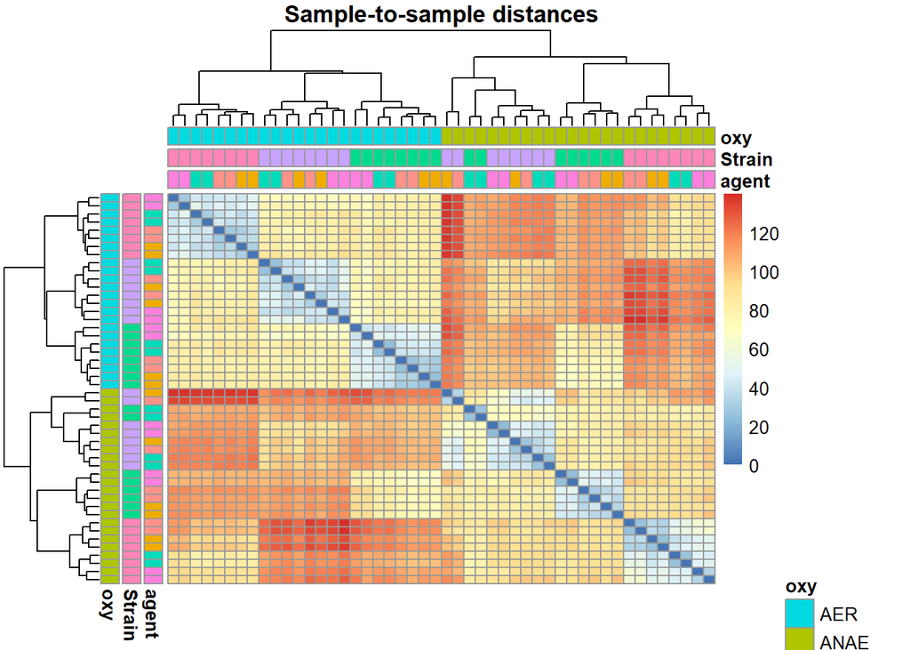

```r
# Sample distance heatmap with readable sample IDs and sample annotations
sampleDists <- dist(t(assay(vsd)))
sampleDistMatrix <- as.matrix(sampleDists)
rownames(sampleDistMatrix) <- colnames(vsd)
colnames(sampleDistMatrix) <- colnames(vsd)

annotation_col <- as.data.frame(colData(vsd))[, c("agent", "Strain", "oxy"), drop = FALSE]
annotation_row <- annotation_col

pheatmap(
  sampleDistMatrix,
  annotation_col = annotation_col,
  annotation_row = annotation_row,
  show_rownames = FALSE,
  show_colnames = FALSE,
  main = "Sample-to-sample distances"
)
```

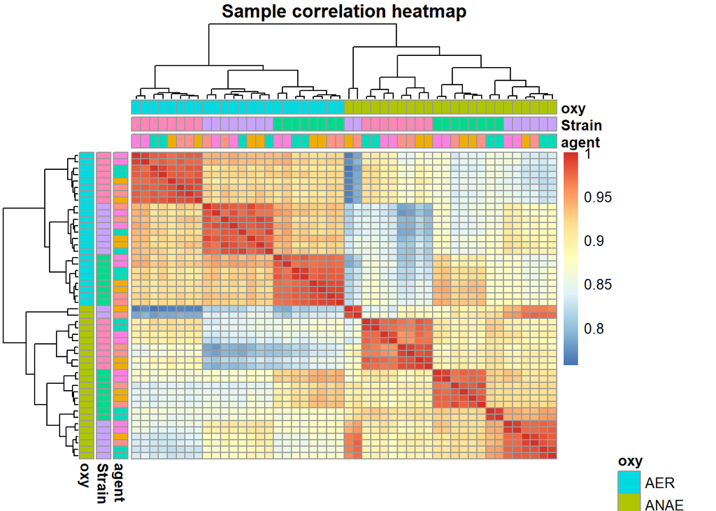

```r
# Correlation heatmap with the same annotations
sampleCor <- cor(assay(vsd))
pheatmap(
  sampleCor,
  annotation_col = annotation_col,
  annotation_row = annotation_row,
  show_rownames = FALSE,
  show_colnames = FALSE,
  main = "Sample correlation heatmap"
)
```

**Question:** What can we learn about the quality of the data from these two graphs? Does it look like we will be able to find differentially expressed genes between aerobic and anaerobic conditions with this data?

We can also check the amount of dispersion between replicate with this type of plots:

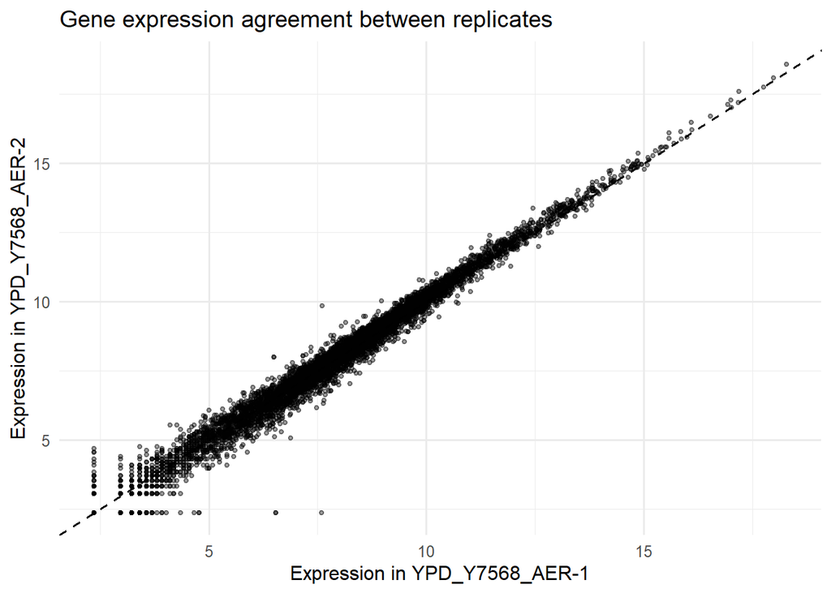

```r
s1 <- "YPD_Y7568_AER-1"
s2 <- "YPD_Y7568_AER-2"

df_rep <- data.frame(
  gene = rownames(vsd),
  rep1 = assay(vsd)[, s1],
  rep2 = assay(vsd)[, s2]
)

ggplot(df_rep, aes(x = rep1, y = rep2)) +
  geom_point(alpha = 0.4, size = 1) +
  geom_abline(slope = 1, intercept = 0, linetype = "dashed") +
  labs(
    x = paste("Expression in", s1),
    y = paste("Expression in", s2),
    title = "Gene expression agreement between replicates"
  ) +
  theme_minimal(base_size = 12)
```

And compare it to the same plot for two samples from diffierent conditions:

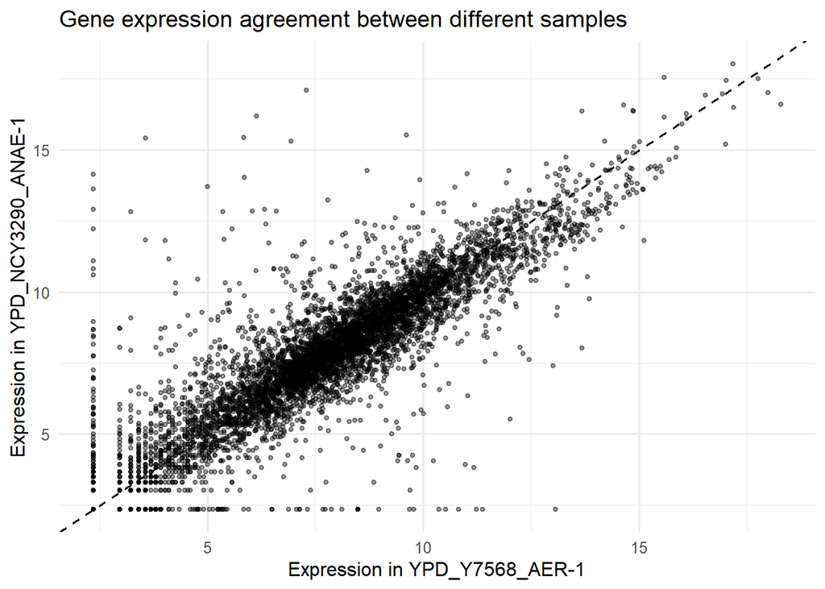

```r
s1 <- "YPD_Y7568_AER-1"
s2 <- "YPD_NCY3290_ANAE-1"

df_rep <- data.frame(
  gene = rownames(vsd),
  rep1 = assay(vsd)[, s1],
  rep2 = assay(vsd)[, s2]
)

ggplot(df_rep, aes(x = rep1, y = rep2)) +
  geom_point(alpha = 0.4, size = 1) +
  geom_abline(slope = 1, intercept = 0, linetype = "dashed") +
  labs(
    x = paste("Expression in", s1),
    y = paste("Expression in", s2),
    title = "Gene expression agreement between different samples"
  ) +
  theme_minimal(base_size = 12)
```

### Volcano plot

A common way to quickly visualize the results of a differential expression experiment is to use a volcano plot. These plots show p-value as a function of the log-fold change for each gene in the experiment:

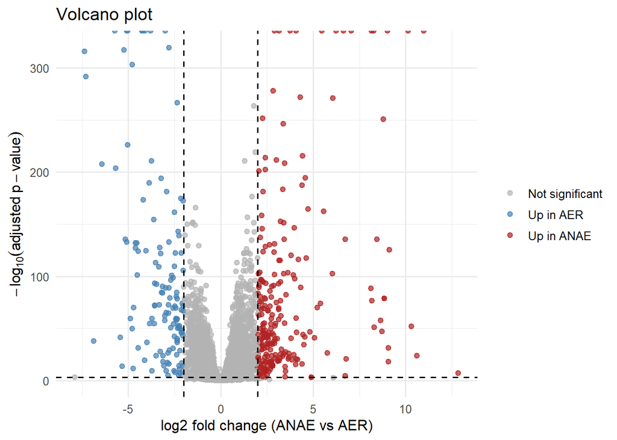

```r
res_df <- as.data.frame(res)
res_df$gene <- rownames(res_df)

MAX_PVAL <- 1e-3

res_df <- res_df %>%
  dplyr::mutate(
    volcano_group = dplyr::case_when(
      !is.na(padj) & padj < MAX_PVAL & log2FoldChange >= 2  ~ "Up in ANAE",
      !is.na(padj) & padj < MAX_PVAL & log2FoldChange <= -2 ~ "Up in AER",
      TRUE ~ "Not significant"
    )
  )

ggplot(res_df, aes(x = log2FoldChange, y = -log10(padj), color = volcano_group)) +
  geom_point(alpha = 0.7, size = 1.8) +
  geom_vline(xintercept = c(-2, 2), linetype = "dashed") +
  geom_hline(yintercept = -log10(MAX_PVAL), linetype = "dashed") +
  scale_color_manual(values = c(
    "Up in ANAE" = "firebrick",
    "Up in AER" = "steelblue",
    "Not significant" = "grey70"
  )) +
  labs(
    x = "log2 fold change (ANAE vs AER)",
    y = expression(-log[10](adjusted~p-value)),
    color = NULL,
    title = "Volcano plot"
  ) +
  theme_minimal(base_size = 12)
```

### Visualizing data

We can look at the abundances for any given gene with the following code:

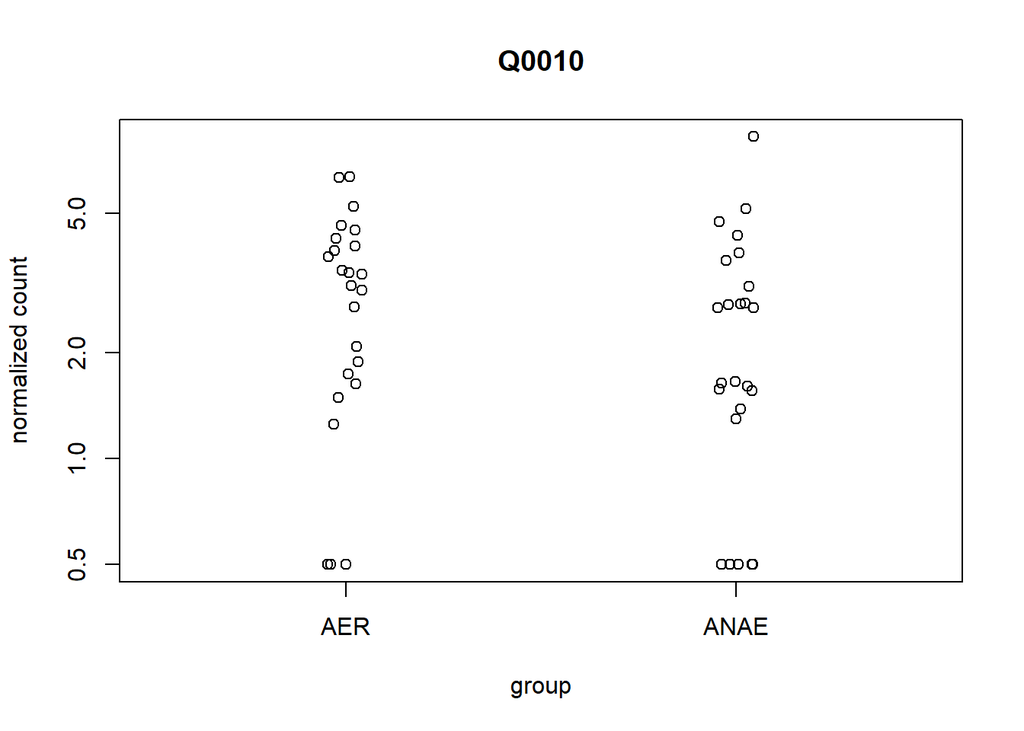

```r
# -----------------------------
# GENE EXPRESSION PLOT
# -----------------------------

geneID <- rownames(res)[1]
plotCounts(dds, gene = geneID, intgroup = "oxy")
```

Now let’s look at the gene with the most significant difference in expression level between aerobic and anaerobic growth conditions:

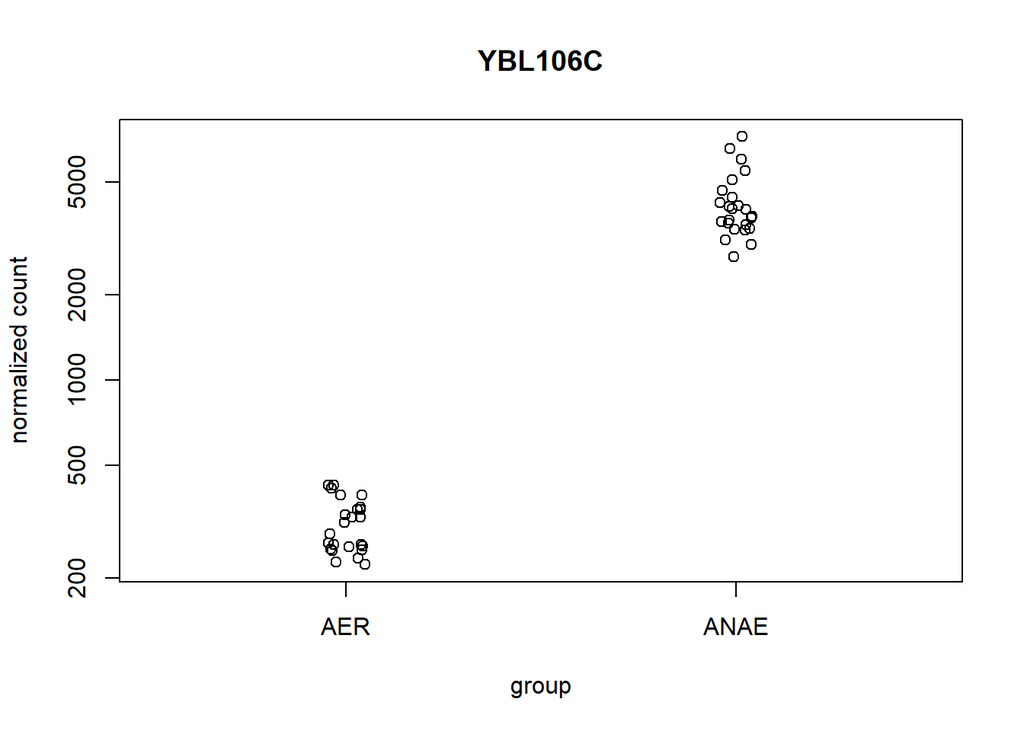

```r
# -----------------------------
# GENE EXPRESSION PLOT
# -----------------------------

geneID <- rownames(res)[which(res$padj==min(res$padj))[1]]
plotCounts(dds, gene = geneID, intgroup = "oxy")
```

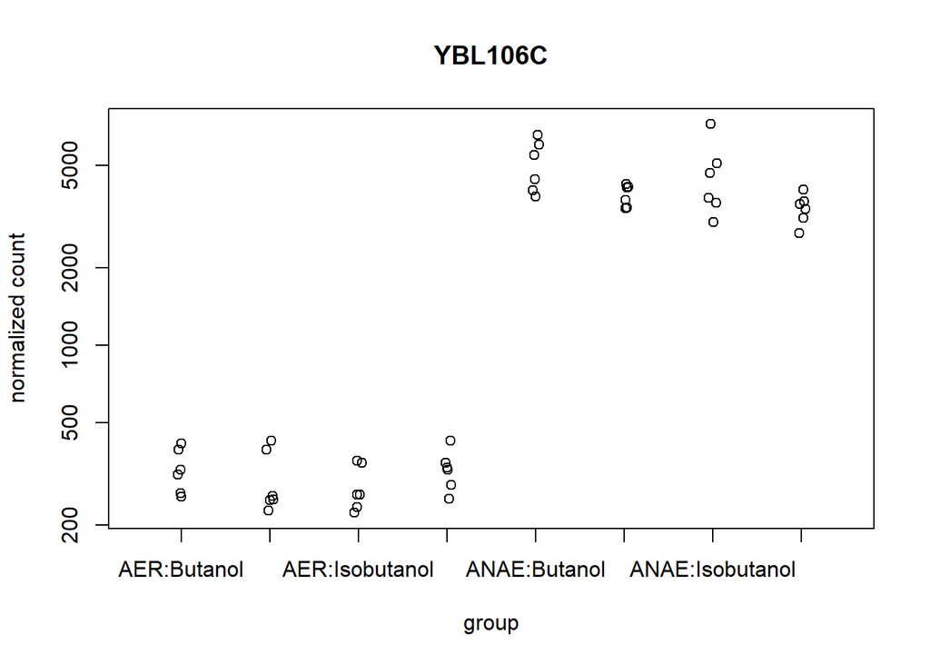

```r
# We can even split the data by aero/aner + agent to see if the increased/decreased expression level is specific to a certain agent
plotCounts(dds, gene=geneID, intgroup=c("oxy", "agent"))
```

Generate a graph showing the transcript abundance as a function of grwoth condition (aer vs anaer) and strain. Does it look like this gene is expressed at a similar level in all the strains tested in this study?

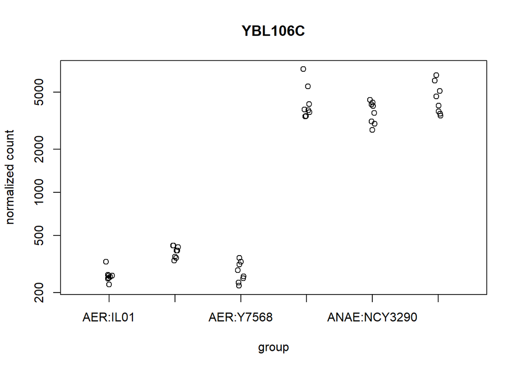

## Exercise:

The 2006 study found that only 5 out of 24 genes tested confer an advantage for anaerobic growth. Here ,we will check that these 24 genes are always up-regulated in anaerobic conditions.

Here is the list of genes from the 2006 study:

```r
# Something annoying with the 2006 is that they mix common gene names (aac3, set4, ...) with systematic IDs (yhl042w, yjr116w, ...)
#
# You can easily find the correspondence "by hand" with: https://www.yeastgenome.org/locus/S000000289
#
# The next few lines of code handle this by getting the list of systematic IDs:
vCommons <- toupper(c("aac3", "cox5b", "ecm34", "fet4", "gsy1", "muc1", "ysr3", "set4", "sml7",
            "sro77", "plb2", "izh2", "eug1"))

vIDs <- toupper(c("ydl241w", "ygl039w", "ygr131w", "yhl042w", "yjr116w", "ylr437c", "ypl272c", "yol101c", "yor013w",  "ylr413w", "yor012w"))

controlGenes <- toupper(c("spr3", "upc2", "dan1", "ura3", "anb1"))

# YGR059w = SPR3

# This function will map the common names (i.e. aac3) with the corresponding ID (i.e. YBR085W)
mapped <- bitr(
  vCommons,
  fromType = "COMMON",
  toType   = "ORF",
  OrgDb    = org.Sc.sgd.db
)

# We know have the list of gene IDs:
vGenesIDs <- c(mapped$ORF, vIDs)
```

I made a mistake in the name of one of the genes, resulting in one mapping operation failing (the authors did not provide an easy way to get the list of genes, I had to read them from the main figure…). How can you find which gene mapping failed? Fix the error and make sure that all your common names are mapped to the corresponding ID.

How many genes from the list used in the 2006 study are differentially expressed in aerobic vs anaerobic conditions based on the data you are currently analyzing? (Use a cutoff of 0.001 for your adjusted p-value).  
Oh, wait! We looked only at the p-value! Could there be genes in the list that are significantly differentially expressed but whose expression level actually goes down when yeast is grown in anaerobic condition?  
Out of the differentially expressed genes (from the list of 24), how many are up vs down-regulated in anaerobic conditions?